# B站“低创”视频创作者识别

狗熊会

为了吸引更多的视频创作者，提供更多种类、质量更好的作品，B站于2018年提出了创作者激励计划。然而，为了进入激励计划，部分用户通过对网络素材的简单拼接和编辑来大规模生产视频，从而快速获得高播放量。这些用户被称为“低创”用户。“低创”用户的出现使得B站视频质量严重下降。因此，本案例将采用聚类方法对B站用户进行细分，在识别出“低创”用户的同时深入了解其他用户的特点，从而对用户做到“精准激励”，达到视频质量和内容升级的目的。

案例中所使用的数据是从B站官网爬取的用户数据，共35,157条，每一条数据代表一个用户信息，每条用户信息包含16个变量

本案例的学习目标包括：

（1）学习使用聚类分析的方法对用户进行细分

（2）学习如何在R中对数据进行描述分析

（3）学习如何在R中进行k-prototypes聚类分析

## 准备工作

```r
# 清除工作环境
cat("\014");rm(list=ls())
```

```r
# 加载需要的包
library(ggplot2) # 画图需要的包
library(ggpubr) # 展示图片需要的包
library(clustMixType) # k-prototypes聚类的包
library(fmsb) # 画雷达图需要的包
```

## 任务一：数据读入

请阅读readme.txt了解数据中各个变量的含义，然后使用read.csv命令读入数据。读入数据后，由于聚类模型需要输入变量值为数值，因此我们需要进一步把里面的“性别”和“生日”两个离散型变量进行因子化处理。最后，使用summary函数对数据中主要的连续型变量（‘following’,‘fans’,‘view’,‘likes’,‘album’,‘article’,‘video’,‘audio’）进行描述性分析。

```r
data1 <- read.csv("data.txt", encoding = 'gbk', sep = ',') # 读入数据
# 性别因子化
data1$sex <- as.factor(data1$sex)
# 由于生日原始格式为09-19 这里我们只要月份信息，因此只取前两个即可
data1$birthday <- sapply(data1$birthday, function(x)substring(x, 1, 2))
data1$birthday <- as.factor(data1$birthday) # 生日因子化
# 查看数据基本信息
summary(data1[c('following','fans','view','likes','album','article','video','audio')])
```

```
##    following           fans              view               likes
##  Min.   :   0.0   Min.   :      0   Min.   :1.000e+00   Min.   :       1
##  1st Qu.:  32.0   1st Qu.:      1   1st Qu.:7.950e+02   1st Qu.:       3
##  Median :  80.0   Median :      5   Median :3.293e+03   Median :      11
##  Mean   : 144.9   Mean   :   2896   Mean   :3.958e+05   Mean   :    9743
##  3rd Qu.: 173.0   3rd Qu.:     36   3rd Qu.:1.704e+04   3rd Qu.:      65
##  Max.   :2000.0   Max.   :4335326   Max.   :1.141e+09   Max.   :17123474
##      album             article              video
##  Min.   :   0.000   Min.   :   0.0000   Min.   :    0.00
##  1st Qu.:   0.000   1st Qu.:   0.0000   1st Qu.:    0.00
##  Median :   0.000   Median :   0.0000   Median :    0.00
##  Mean   :   5.754   Mean   :   0.4338   Mean   :   14.69
##  3rd Qu.:   1.000   3rd Qu.:   0.0000   3rd Qu.:    4.00
##  Max.   :5704.000   Max.   :1475.0000   Max.   :11115.00
##      audio
##  Min.   :  0.0000
##  1st Qu.:  0.0000
##  Median :  0.0000
##  Mean   :  0.1803
##  3rd Qu.:  0.0000
##  Max.   :334.0000
```

## 任务二：描述性分析

以“用户等级”为例进行描述性分析。B站的“创作者激励计划”是指：在B站中拥有1500个粉丝以上或视频播放总量15万以上的用户即可申请加入激励计划。可以看到，激励计划在“粉丝数”和“视频播放量”两个指标上对用户有要求。因此，请在本任务中探究“用户等级”与“粉丝数”、“视频播放量”两个指标的关系。你可以使用分组箱线图来完成这个分析，并对两个统计图进行解读。注意，由于“粉丝数”，“视频播放量”不同用户之间差距巨大，可以使用对数变换之后的数据进行箱线图展示。

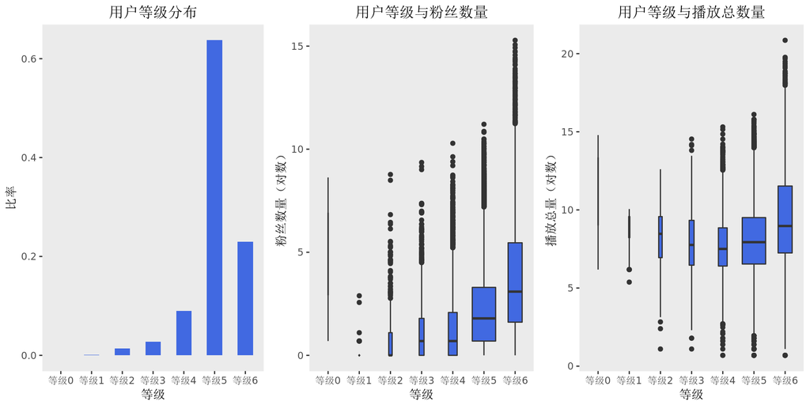

```r
# 通过level变量分组，并统计每一个组的样本数量
numy <- data.frame(table(data1['level']))
names(numy) <- c("level", "level_cnt") # 变更统计数据框的变量名
# numx存储level的值
numx <- numy$level
label <- numx
# 第一张图：用户等级分布柱状图
p1 <- ggplot(aes(x = paste0('等级',level), y = level_cnt/sum(level_cnt)), data = numy) +
  geom_bar(stat="identity", fill = 'royalblue', width = 0.5) + xlab('等级') + ylab('比率') +
  ggtitle("用户等级分布") + theme(plot.title = element_text(hjust = 0.5)) + # 标题居中
  theme(panel.grid.major=element_blank(),panel.grid.minor=element_blank()) # 去掉网格


# 第二张图，用户等级与粉丝数量箱线图
fans_level <- data.frame()
# fans_level 用来存储每一个等级类别的粉丝数据，用于之后箱线图展示
# 对每一个等级对应粉丝数取对数
for(i in numx){
  fans_level_tmp <- data.frame(level = rep(i, length(data1[data1$level == i,]$fans)),fans_level = log(data1[data1$level == i,]$fans + 1))
  fans_level <- rbind(fans_level, fans_level_tmp)
}
p2 <- ggplot(aes(x = paste0('等级',level), y = fans_level), data = fans_level) +
  geom_boxplot(fill = 'royalblue', varwidth = sqrt(fans_level$fans_level/200),outlier.fill = 'red') + xlab('等级') + ylab('粉丝数量（对数）') +
  ggtitle('用户等级与粉丝数量') +  theme(plot.title = element_text(hjust = 0.5))+ # 标题居中
  theme(panel.grid.major=element_blank(),panel.grid.minor=element_blank()) # 去掉网格

# 第三张图，用户等级与播放总数量的箱线图
fans_level <- data.frame()
# fans_level 用来存储每一个等级类别的播放总数量，用于之后箱线图展示
for(i in numx){
  fans_level_tmp <- data.frame(level = rep(i, length(data1[data1$level == i,]$view)),fans_level = log(data1[data1$level == i,]$view + 1))
  fans_level <- rbind(fans_level, fans_level_tmp)
}
p3 <- ggplot(aes(x = paste0('等级',level), y = fans_level), data = fans_level) + geom_boxplot(fill = 'royalblue', varwidth = sqrt(fans_level$fans_level/200),outlier.fill = 'red') +
  xlab('等级') + ylab('播放总量（对数）')+
  ggtitle('用户等级与播放总数量') + theme(plot.title = element_text(hjust = 0.5))+ # 标题居中
  theme(panel.grid.major=element_blank(),panel.grid.minor=element_blank()) # 去掉网格

## 展示图
ggarrange(p1, p2, p3, ncol = 3, nrow = 1, widths = 1.5)
```

#### 【解读参考】：

在用户等级上，等级为5、6 的用户数量明显高于其他等级，这里由于用户数据是按照用户的id依次爬取，因而数据中的用户均是B站成立初期的用户，从而出现用户等级在 5、6 中数量非常多的现象。从后两张图中可见，B 站中的用户等级是根据用户在 B 站的活跃程度进行评级的一个结果，因此越活跃的用户往往具有越多的粉丝或者越多的播放量。通过描述分析可以看到，用户等级可以作为一个区别用户类别的变量。

## 任务三：生成衍生指标

根据原始数据生成四个衍生指标，即获赞率、粉丝留存率、播放量、作品总数。每个衍生指标的具体计算方法如下：

粉丝留存率 = 粉丝数/视频播放量

获赞率 = 获赞数/视频播放量

平均播放量 = 作品总播放量/总作品数

总作品数 = 用户作品的加和

生成衍生指标之后，请使用直方图展示获赞率、粉丝留存率、播放量三个变量的分布情况。你可以先尝试绘制原始取值的分布情况，你会发现这三个变量都是严重右偏的。为此，可以对各个变量取对数之后，再绘制直方图。根据各个直方图，你能发现什么？

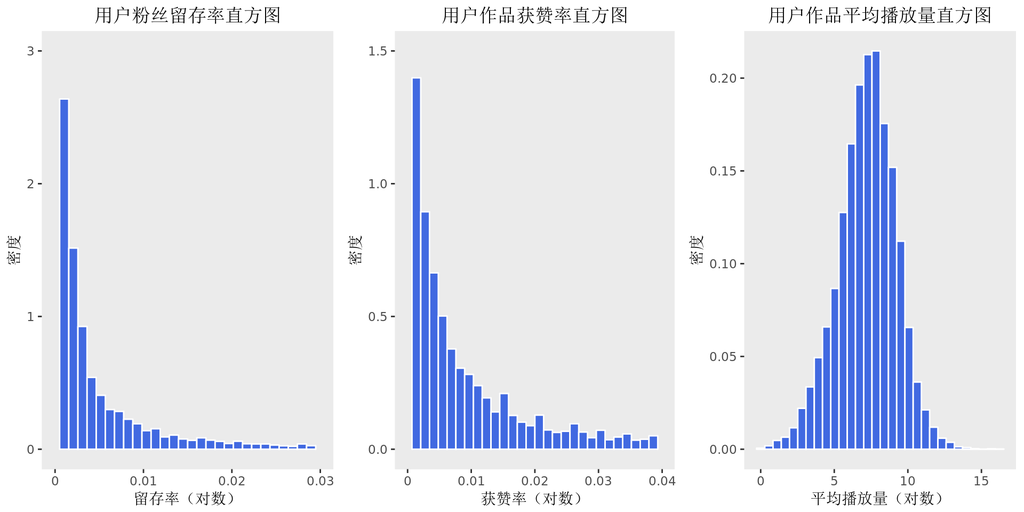

```r
data1['wpr'] = ((data1['likes']+1)/data1['view']) # 获赞率，有些获赞量为0，之后对数变换会有问题，因而均加一处理
data1['ftr'] = ((data1['fans']+1)/data1['view']) # 粉丝留存率
data1['apr'] = data1['view']/(data1['album']+data1['article']+data1['video']+data1['audio']+1) # 平均播放量 总作品量可能为0，因此也加一处理
data1['sum'] = data1['album']+data1['article']+data1['video']+data1['audio'] # 作品总数量

# 用户粉丝留存率直方图
p1 <- ggplot(aes(log(ftr + 1)*100), data = data1) +
  geom_histogram(aes(y=..density..),fill = 'royalblue',color = 'white',bins = 30) +
   xlab('留存率（对数）') + ylab('密度')  + ylim(0,3)+ # 设定y轴范围
  scale_x_continuous(limits = c(0,3), breaks = c(0,1,2,3), labels = c(0,0.01,0.02,0.03))+ # 设定x轴标签
  ggtitle('用户粉丝留存率直方图') + theme(plot.title = element_text(hjust = 0.5))+ # 标题居中
  theme(panel.grid.major=element_blank(),panel.grid.minor=element_blank()) # 去掉网格线

# 用户作品获赞率直方图
p2 <- ggplot(aes(log(wpr + 1)*100), data = data1) +
  geom_histogram(aes(y=..density..),fill = 'royalblue',color = 'white', bins = 30) +
   xlab('获赞率（对数）') + ylab('密度')  + ylim(0,1.5) + # y轴范围
  scale_x_continuous(limits = c(0,4), breaks = c(0,1,2,3,4), labels = c(0,0.01,0.02,0.03,0.04))+ # 设定x轴标签
  ggtitle('用户作品获赞率直方图') + theme(plot.title = element_text(hjust = 0.5)) +  # 标题居中
  theme(panel.grid.major=element_blank(),panel.grid.minor=element_blank()) # 去掉网格线

# 用户作品平均播放量直方图
p3 <- ggplot(aes(log(apr + 1)), data = data1) +
  geom_histogram(aes(y=..density..),fill = 'royalblue',color = 'white',bins = 30) +
   xlab('平均播放量（对数）') + ylab('密度') +
  ggtitle('用户作品平均播放量直方图') + theme(plot.title = element_text(hjust = 0.5)) + # 用户居中
  theme(panel.grid.major=element_blank(),panel.grid.minor=element_blank()) # 去掉网格线

## 展示图
ggarrange(p1, p2, p3, ncol = 3, nrow = 1)
```

#### 【解读参考】：

对数变换后，用户粉丝留存率和获赞率仍然呈现明显的右偏分布，但用户平均播放量呈现对称分布的特点。

## 任务四：建立聚类模型

选取聚类主题数K=4，建立聚类模型。在进行聚类时，我们使用的变量包括：“性别”、“生日”、“等级”、“种类“、”视频数量“、“相册数量”、“文章数量”、“总作品数量”、“粉丝人数”、“关注人数“、“获赞数量”、“总播放量”、“平均播放量”、“获赞率”、“粉丝留存率”16个变量，由于变量中既包含离散型变量，又包含连续型变量，因此使用k-prototypes聚类方法，你可以通过调用clustMixType里面的kproto函数来建立该模型。

在聚类之前，需要对数据做如下预处理：

（1）去掉数据中的NA值；

（2）对于离散型变量，将其转化为character类别，为聚类准备；

（3）对于连续型变量/整数变量，将其做对数变换。

聚类之后，展示四个类别在’获赞率’,‘粉丝留存率’,‘均播放量’,‘粉丝人数’,‘播放量’,‘获赞数’,’总作品数’7个变量上的类别中心取值。

```r
# 聚类之前，将存在空值的数据去掉（之前填充的只有获赞量与播放量）
data1 <- na.omit(data1)
# 三类变量需要不同的处理方式，以下三个变量用于存储他们的名称以便之后提取这些变量
# 离散变量名称（类别型）
qualitative <- c('sex','types','level','birthday')
# 连续变量名称（计数型）
numerical <- c('following','fans','view','likes','album','article','video','audio','sum')
# 连续变量名称
continuous <- c('wpr','ftr','apr')

# 提取三类变量
data_qual <- data1[,qualitative]
data_nume <- data1[,numerical]
data_conti <- data1[,continuous]

# 将离散变量转为character
for(i in names(data_qual)){
   data_qual[,i] <- as.factor(data_qual[,i])
}

# 将整数变量与连续变量均采取对数变换
data_nume <- log(data_nume+1)
data_conti <- log(data_conti)
# 连接三类数据，并重置数据索引
data <- cbind(data_conti, data_nume, data_qual)


# 聚类
set.seed(1234) # 设定随机种子
kpres <- kproto(data, 4, verbose=FALSE) # k_prototype聚类,设定类别数为4
cluster_res <- kpres$cluster # 各个样本聚类结果存储
center <- kpres$centers # 聚类中心存储

# 展示聚类中心
# 聚类中心还原
dat_center <- center
dat_center[,c(names(data_conti))] <- round(exp(dat_center[,c(names(data_conti))]),3)
dat_center[,c(names(data_nume))] <- round(exp(dat_center[,c(names(data_nume))])-1,3)
# 选取需要展示的列
dat_center <- dat_center[,c('wpr','ftr','apr','fans','view','likes','sum')]
# 更改列名，便于展示
names(dat_center) <- c('获赞率','粉丝留存率','均播放量','粉丝人数','播放量','获赞数','总作品数')
# 增加定义用户类别的列
dat_center <- cbind( '用户类别' = c('第一类用户','第二类用户','第三类用户','第四类用户'),dat_center)

dat_center # 展示数据
```

```
##     用户类别 获赞率 粉丝留存率 均播放量 粉丝人数     播放量   获赞数
## 1 第一类用户  0.003      0.001 2444.313    2.377   3270.172    7.596
## 2 第二类用户  0.030      0.019  120.128    3.474    243.530    6.284
## 3 第三类用户  0.004      0.002 3793.056   80.078  34782.907  129.286
## 4 第四类用户  0.014      0.005 8397.532 3568.533 706668.921 9569.095
##   总作品数
## 1    0.338
## 2    1.009
## 3    8.170
## 4   83.152
```

## 任务五：类别解读

为了观察每类用户的特点，我们可以通过雷达图展示各个类别在某些重点变量上的取值特点。具体来说，我们可以选取：‘获赞率’,‘粉丝留存率’,‘均播放量’,‘粉丝人数’,‘播放量’,‘获赞数’,’总作品数’共七个变量的类中心情况进行展示。对于任意一个变量，首先对其在四个类别的类中心取值进行“最小最大值”的标准化处理，即(x-min)/(max-min)，这样各个类中心取值都在0~1之间变动，从而方便的在雷达图中进行对比。

绘制各个类在上述7个变量上的雷达图（可以根据上一个任务中的类中心取值），然后根据雷达图的情况，概括总结每个类的特点。

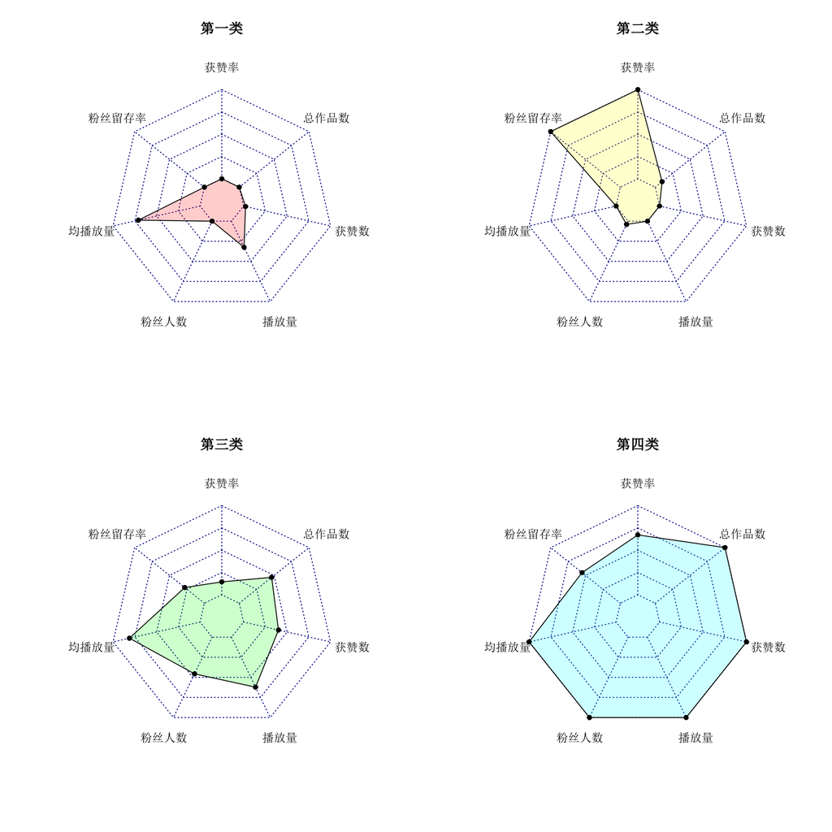

```r
# 提取需要展示的数据
dat <- center[,c('wpr','ftr','apr','fans','view','likes','sum')]
# 数据框重命名
names(dat) <- c('获赞率','粉丝留存率','均播放量','粉丝人数','播放量','获赞数','总作品数')
## 数据标准化处理
dat <- data.frame(apply(dat, 2, function(x)(x-min(x))/(max(x)-min(x))))
dat_max <- apply(dat, 2, max) # 最大值
dat_min <- apply(dat, 2, min) # 最小值
# 雷达图数据格式：第一行最大值，第二行最小值
dat_res <- rbind(dat_max, dat_min, dat)

# 设定画图格式为两行两列
par(mfrow = c(2, 2))
color_1 <- rainbow(6,alpha=0.2) # 设定颜色
# 画四类人群的雷达图，pfcolor控制颜色
radarchart(df = dat_res[c(1,2,3),],title = "第一类", pfcol = color_1[1])
radarchart(df = dat_res[c(1,2,4),],title = "第二类", pfcol = color_1[2])
radarchart(df = dat_res[c(1,2,5),],title = "第三类", pfcol = color_1[3])
radarchart(df = dat_res[c(1,2,6),],title = "第四类", pfcol = color_1[4])
```

#### 【解读参考】：

第三类用户介于三者之间，构成较为复杂，实际上是一种过渡的用户，不适于对这类用户进行简单地归类，这里将这一类用户称为过渡用户。

第四类用户具有超高播放量，超高粉丝量。其作品数量较多，质量也呈现了参差不齐的情况，因而这一类用户在获赞率与粉丝留存率上并不一定很高，将这一类用户称为up主用户。

## 任务六：附加题

为了更直观的展示四类用户的特点，重点考察粉丝数、播放量、粉丝留存率、获赞率四个判定“低创”用户的重要变量在四类用户上的分布情况。你可以绘制两张散点图，分别是：粉丝数（对数）V.S.播放量（对数），粉丝留存率（对数）V.S.获赞率（对数）。在每个图中，各个类别用户的散点可以用不同颜色标记出来，相应的类别中心可以用某种特殊形状的符号（比如五角星）标记。这样，我们就能非常清晰的看到每类用户在上述几个变量上的分布情况。从这两个图中，你能得到哪些结论？

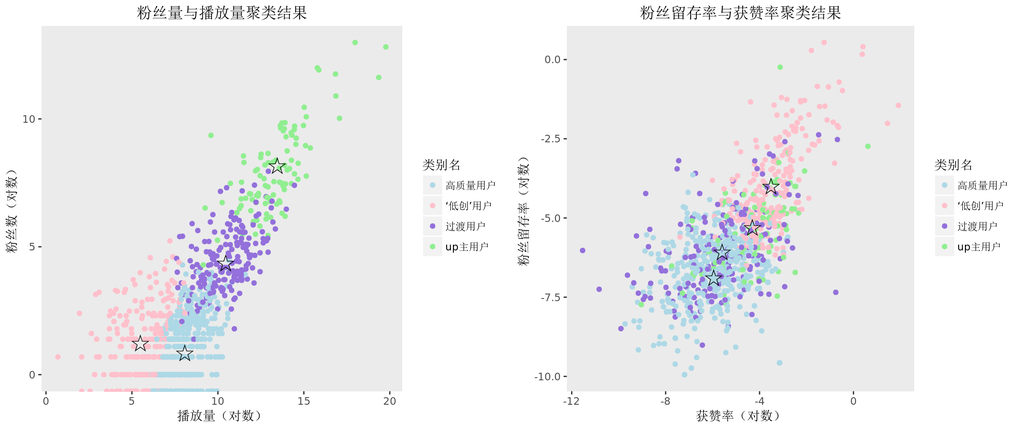

```r
# 设定画图需要的数据框：原始数据 + 聚类结果
data_plot <- cbind(data1, cluster_res)
# 为聚类后的四类人群设定标签
labels <-  c("高质量用户","‘低创’用户","过渡用户","up主用户")
# 将聚类结果转化为因子
data_plot$cluster_res <- factor(cluster_res,levels = c(1,2,3,4),
                                labels = labels)

# 聚类中心还原
center[,c(names(data_conti))] <- exp(center[,c(names(data_conti))])
center[,c(names(data_nume))] <- exp(center[,c(names(data_nume))])-1
# 设定画图需要的聚类中心数据框：聚类中心 + 聚类结果
# 将聚类结果转化为因子
center_plot <- cbind(center, cluster_res = c(1,2,3,4))
center_plot$cluster_res <- factor(center_plot$cluster_res,levels = c(1,2,3,4),
                                labels = labels)

# 随机选取1000条数据画图
n=1000
set.seed(1) # 为了重现图像，设置随机种子
# 原数据集太大无法全部展示，因而从原始数据中抽取1000个样本
data_plot <- data_plot[sample(1:dim(data_plot)[1], n, replace = FALSE),]

# 粉丝量与播放量聚类结果图
p1 <- ggplot(aes(x = log(view), y = log(fans),color = as.factor(cluster_res)),data = data_plot) + geom_point()+scale_color_manual(values = c('lightblue','pink','mediumpurple','lightgreen')) + # 设定四类颜色
  xlab('播放量（对数）') + ylab('粉丝数（对数）') +
  ggtitle('粉丝量与播放量聚类结果') + theme(plot.title = element_text(hjust = 0.5)) +  # 标题居中
  theme(panel.grid.major=element_blank(),panel.grid.minor=element_blank()) + labs(color="类别名") +
  geom_text(data = center_plot, aes(label =  rep("☆",4),x = log(view), y = log(fans)), color = 'black', size = 7)  # geom_text()是以文字的形式加在图中加上聚类中心

# 粉丝留存率与获赞率聚类结果
p2 <- ggplot(aes(x = log(wpr),y = log(ftr),color = as.factor(cluster_res)),data = data_plot) +
  geom_point() + scale_color_manual(values = c('lightblue','pink','mediumpurple','lightgreen')) + xlab('获赞率（对数）') + ylab('粉丝留存率（对数）') + ggtitle('粉丝留存率与获赞率聚类结果') +
  theme(plot.title = element_text(hjust = 0.5)) +
  theme(panel.grid.major=element_blank(),panel.grid.minor=element_blank()) + labs(color="类别名") +
  geom_text(data = center_plot, aes(label = rep("☆",4), x=log(wpr), y = log(ftr)), color = 'black', size = 7)

## 展示图
ggarrange(p1, p2, ncol = 2, nrow = 1)
```